# Gastos Casa

21 November, 2026

# 1. Control de gasto

```r
# Cada gasto se clasifica por su contenido: expresión regular sobre el texto en minúsculas y sin tildes.
# Las reglas se evalúan en orden y gana la primera que calza; para sumar un ítem basta agregar su palabra aquí.
reglas_categoria <- c(
  "Diosi"                             = "diosi",
  "Entretención"                      = "nintendo|playstation|steam|videojuego",
  "Transporte"                        = "uber|cabify|transporte|bencina|\\btag\\b|peaje|autopista|estacionamiento|viaje|assistcard",
  "Electrodomesticos/mantencion casa" = "electrodomestic|mantencion|aspiradora|microondas|mueble|mouse|reloj|cortina|filtro|toyotomi|alfombra|sopapo|\\bpila|jardiner|camara|\\btina\\b|nacho|lamina|chromecast|\\beasy\\b|sodimac|arreglo|gasfiter|lavadora|secadora|malla|chapa|cerrajer|biblioteca",
  "Farmacia"                          = "farmacia|remedio|\\byaz\\b|nexium|vacuna|gaviscon|paracetamol|cruz verde|salcobrand",
  "Streaming/Telefonia"               = "vtr|netflix|crunchyroll|entel|internet|spotify|disney|celular|telefon",
  "Servicios básicos"                 = "electricidad|\\bluz\\b|\\benel\\b|\\bgas\\b|parafina|kerosen|agua",
  "Comida"                            = "comida|supermercado|\\bsuper\\b|jumbo|lider|unimarc|tottus|\\bpan\\b|pepperino|cookidoo|granola|wild|brussels",
  "Enceres"                           = "enceres|incoludido|tres toques",
  "Donaciones/regalos"                = "basurero|donacion|regalo|rgalo|matri|\\bropa\\b|aporte|reciclaje"
)

categoriza <- function(x) {
  x <- dplyr::coalesce(as.character(x), "") %>%
    stringr::str_to_lower() %>%
    stringi::stri_trans_general("Latin-ASCII") %>%
    stringr::str_squish()
  out <- rep(NA_character_, length(x))
  for (cat in names(reglas_categoria)) {
    out[is.na(out) & stringr::str_detect(x, reglas_categoria[[cat]])] <- cat
  }
  out
}

stopifnot(identical(
  categoriza(c("Gas/Bencina", "Gas", "Filtro agua", "Uber matri Cony", "Nintendo online", "Remedios", "Préstamo")),
  c("Transporte", "Servicios básicos", "Electrodomesticos/mantencion casa", "Transporte", "Entretención", "Farmacia", NA)
))

# Primero manda el ítem; la observación solo se usa si el ítem no calza con ninguna regla
Gastos_casa <- Gastos_casa %>%
  dplyr::mutate(
    fecha_d   = as.Date(lubridate::parse_date_time(fecha, "%d/%m/%Y", exact = TRUE)),
    mes       = lubridate::floor_date(fecha_d, "month"),
    categoria = dplyr::coalesce(categoriza(gasto), categoriza(obs), "Otros")
  )
```

Últimos 30 movimientos registrados:

```r
Gastos_casa %>%
  dplyr::select(-Tiempo,-link) %>%
  dplyr::select(fecha, gasto, monto, gastador,obs) %>% tail(30) %>%
  knitr::kable(format = "markdown", size=12)
```

| fecha | gasto | monto | gastador | obs |
| --- | --- | --- | --- | --- |
| 6/9/2026 | Comida | 85794 | Tami | Supermercado |
| 11/9/2026 | Nintendo online | 20990 | Tami | Nintendo online |
| 12/9/2026 | Comida | 118332 | Tami | Supermercado |
| 12/9/2026 | Diosi | 19681 | Tami | Antiparasitario |
| 13/9/2026 | Nintendo | 295378 | Tami | Nintendo Switch |
| 13/9/2026 | Nintendo | 295378 | Andrés | Nintendo |
| 13/9/2026 | Nintendo | 295378 | Andrés | Nintendo |
| 13/9/2026 | Nintendo | 295378 | Andrés | Nintendo |
| 17/9/2026 | Comida | 78459 | Tami | Supermercado |
| 24/9/2026 | Comida | 55474 | Tami | Jumbo Maite |
| 22/9/2026 | Gas/Bencina | 37430 | Tami | Bencina Maie |
| 24/9/2026 | Comida | 27185 | Andrés | maite compra |
| 30/9/2026 | Comida | 12000 | Andrés | 15.070/2 + 5.500/2 |
| 4/10/2026 | Comida | 61556 | Tami | Supermercado |
| 5/10/2026 | Comida | 76008 | Tami | Wild Foods |
| 10/10/2026 | Comida | 142922 | Tami | Supermercado |
| 11/10/2026 | Transporte | 10164 | Tami | TAG |
| 11/10/2026 | Diosi | 18075 | Tami | Remedio Diosi (Julio, Agosto, Septiembre) |
| 16/10/2026 | VTR | 16000 | Andrés | NA |
| 16/10/2026 | Diosi | 45390 | Andrés | Comida Diosi |
| 17/10/2026 | Comida | 82030 | Tami | Supermercado |
| 22/10/2026 | Autopista Nogales-Puchincaví | 4900 | Tami | Autopista Nogales |
| 22/10/2026 | Diosi | 5319 | Tami | Remedio Diosi Octubre |
| 24/10/2026 | Comida | 66505 | Tami | Supermercado |
| 31/10/2026 | Comida | 94448 | Tami | Supermercado |
| 3/11/2026 | Diosi | 17780 | Andrés | wuwu arena 7kg 2 unidades |
| 7/11/2026 | Comida | 107000 | Tami | Supermercado |
| 14/11/2026 | Comida | 102631 | Tami | Supermercado |
| 31/3/2019 | Comida | 9000 | Andrés | NA |
| 8/9/2019 | Comida | 24588 | Andrés | Super Lider |

## Gasto por categoría

```r
mes_actual <- lubridate::floor_date(Sys.Date(), "month")

gasto_mes_cat <- Gastos_casa %>%
  dplyr::filter(!is.na(mes), mes <= mes_actual) %>%
  dplyr::group_by(mes, categoria) %>%
  dplyr::summarise(gasto = sum(monto, na.rm = TRUE), .groups = "drop") %>%
  tidyr::complete(mes = seq(min(mes), mes_actual, by = "month"), categoria, fill = list(gasto = 0))

prom_12m <- gasto_mes_cat %>%
  dplyr::filter(mes < mes_actual, mes >= mes_actual %m-% months(12)) %>%
  dplyr::group_by(categoria) %>%
  dplyr::summarise(`Promedio 12 meses` = mean(gasto))

gasto_mes_cat %>%
  dplyr::filter(mes >= mes_actual %m-% months(3)) %>%
  dplyr::mutate(columna = paste0(format(mes, "%m/%Y"), ifelse(mes == mes_actual, " (en curso)", ""))) %>%
  dplyr::select(-mes) %>%
  tidyr::pivot_wider(names_from = columna, values_from = gasto) %>%
  dplyr::left_join(prom_12m, by = "categoria") %>%
  dplyr::relocate(`Promedio 12 meses`, .after = categoria) %>%
  dplyr::arrange(dplyr::desc(`Promedio 12 meses`)) %>%
  janitor::adorn_totals() %>%
  dplyr::mutate(dplyr::across(-categoria, ~ .x / 1000)) %>%
  dplyr::rename(`Categoría` = categoria) %>%
  knitr::kable("markdown", digits = 0,
               caption = "Gasto por categoría en miles de pesos: promedio de los últimos 12 meses completos, últimos 3 meses y mes en curso")
```

Gasto por categoría en miles de pesos: promedio de los últimos 12 meses completos, últimos 3 meses y mes en curso

| Categoría | Promedio 12 meses | 08/2026 | 09/2026 | 10/2026 | 11/2026 (en curso) |
| --- | --- | --- | --- | --- | --- |
| Comida | 431 | 506 | 389 | 523 | 210 |
| Entretención | 100 | 0 | 1203 | 0 | 0 |
| Electrodomesticos/mantencion casa | 83 | 0 | 0 | 0 | 0 |
| Diosi | 71 | 146 | 38 | 69 | 18 |
| Servicios básicos | 35 | 0 | 0 | 0 | 0 |
| Streaming/Telefonia | 15 | 0 | 17 | 16 | 0 |
| Transporte | 13 | 0 | 37 | 15 | 0 |
| Otros | 11 | 0 | 0 | 0 | 0 |
| Enceres | 6 | 0 | 0 | 0 | 0 |
| Donaciones/regalos | 1 | 0 | 0 | 0 | 0 |
| Farmacia | 0 | 0 | 0 | 0 | 0 |
| Total | 766 | 652 | 1685 | 623 | 227 |

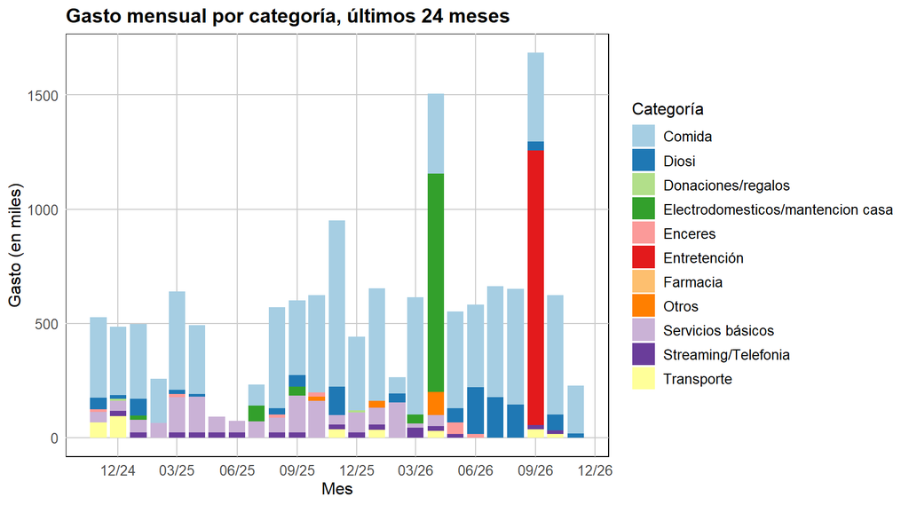

```r
gasto_mes_cat %>%
  dplyr::filter(mes >= mes_actual %m-% months(24)) %>%
  ggplot(aes(x = mes, y = gasto / 1000, fill = categoria)) +
  geom_col() +
  scale_fill_brewer(palette = "Paired") +
  scale_x_date(date_breaks = "3 months", date_labels = "%m/%y") +
  labs(x = "Mes", y = "Gasto (en miles)", fill = "Categoría",
       title = "Gasto mensual por categoría, últimos 24 meses") +
  theme_custom()
```

```r
gasto_mes_cat %>%
  dplyr::filter(mes < mes_actual) %>%
  dplyr::group_by(categoria, anio = format(mes, "%Y")) %>%
  dplyr::summarise(gasto = mean(gasto) / 1000, .groups = "drop") %>%
  tidyr::pivot_wider(names_from = anio, values_from = gasto) %>%
  janitor::adorn_totals() %>%
  dplyr::rename(`Categoría` = categoria) %>%
  knitr::kable("markdown", digits = 0,
               caption = "Gasto promedio mensual por categoría y año, en miles de pesos (los meses sin gasto cuentan como cero)")
```

Gasto promedio mensual por categoría y año, en miles de pesos (los meses sin gasto cuentan como cero)

| Categoría | 2019 | 2020 | 2021 | 2022 | 2023 | 2024 | 2025 | 2026 |
| --- | --- | --- | --- | --- | --- | --- | --- | --- |
| Comida | 208 | 393 | 318 | 312 | 366 | 327 | 299 | 412 |
| Diosi | 34 | 37 | 53 | 31 | 56 | 33 | 25 | 73 |
| Donaciones/regalos | 0 | 9 | 14 | 12 | 8 | 8 | 1 | 0 |
| Electrodomesticos/mantencion casa | 0 | 10 | 57 | 9 | 15 | 11 | 11 | 100 |
| Enceres | 56 | 39 | 15 | 24 | 18 | 24 | 4 | 7 |
| Entretención | 0 | 0 | 0 | 0 | 0 | 0 | 0 | 120 |
| Farmacia | 0 | 14 | 14 | 3 | 11 | 0 | 0 | 0 |
| Otros | 0 | 0 | 0 | 5 | 1 | 69 | 2 | 13 |
| Servicios básicos | 44 | 48 | 49 | 95 | 79 | 129 | 95 | 29 |
| Streaming/Telefonia | 13 | 27 | 26 | 32 | 22 | 20 | 16 | 14 |
| Transporte | 0 | 0 | 0 | 6 | 14 | 113 | 3 | 12 |
| Total | 356 | 576 | 545 | 531 | 588 | 733 | 456 | 780 |

## Gastos sin clasificar

Ítems que no calzan con ninguna regla y quedan en “Otros”. Si alguno pesa, se agrega su palabra a `reglas_categoria`.

```r
Gastos_casa %>%
  dplyr::filter(categoria == "Otros") %>%
  dplyr::group_by(gasto, obs) %>%
  dplyr::summarise(veces = dplyr::n(), total = sum(monto, na.rm = TRUE), ultima = max(fecha_d, na.rm = TRUE), .groups = "drop") %>%
  dplyr::arrange(dplyr::desc(total)) %>%
  knitr::kable("markdown", col.names = c("Ítem", "Observación", "Veces", "Total", "Última fecha"),
               format.args = list(big.mark = ".", decimal.mark = ","))
```

| Ítem | Observación | Veces | Total | Última fecha |
| --- | --- | --- | --- | --- |
| Otros | aire | 1 | 285.000 | 2024-08-23 |
| prestamo | NA | 1 | 242.000 | 2024-04-23 |
| Otros | instalacion | 1 | 170.000 | 2024-08-23 |
| Préstamo Andrés | NA | 1 | 122.000 | 2024-04-27 |
| Otros | flete | 1 | 75.000 | 2026-04-16 |
| Transferencia | Deposito 30 lks | 1 | 60.000 | 2022-11-20 |
| Otros | Aseo Maite | 1 | 30.000 | 2026-01-26 |
| Otros | control remoto | 1 | 25.000 | 2026-04-20 |
| Otros | alfred anual | 1 | 18.275 | 2025-10-22 |
| correo | correos de chile raul miranda | 1 | 8.000 | 2023-07-09 |
| cartero | NA | 1 | 4.000 | 2024-05-28 |

# 2. UF proyectada

UF promedio mensual según el SII. Sirve para descontar la inflación del gasto y para reajustar la proyección.

```r
lee_uf <- function(anio) {
  tablas <- rvest::read_html(paste0("https://www.sii.cl/valores_y_fechas/uf/uf", anio, ".htm")) %>%
    rvest::html_nodes("table")
  tablas[[length(tablas)]] %>%
    rvest::html_table() %>%
    data.frame() %>%
    dplyr::mutate(dplyr::across(dplyr::everything(), as.character)) %>%
    reshape2::melt(id.vars = 1) %>%
    stats::setNames(c("dia", "mes", "valor")) %>%
    dplyr::mutate(anio = anio)
}

meses_uf <- c(ene = 1, feb = 2, mar = 3, abr = 4, may = 5, jun = 6, jul = 7, ago = 8, sep = 9, oct = 10, nov = 11, dic = 12)

uf_serie <- purrr::map_dfr(2018:lubridate::year(Sys.Date()), lee_uf) %>%
  dplyr::transmute(
    fecha = lubridate::make_date(anio, meses_uf[tolower(mes)], as.integer(dia)),
    uf    = readr::parse_number(valor, locale = readr::locale(decimal_mark = ",", grouping_mark = "."))
  ) %>%
  dplyr::filter(!is.na(fecha), !is.na(uf)) %>%
  dplyr::arrange(fecha)

# Si falta un día, la serie queda corrida y la proyección sale mal sin avisar
stopifnot(nrow(uf_serie) > 0, all(diff(uf_serie$fecha) == 1))

uf_mensual <- uf_serie %>%
  dplyr::group_by(mes = lubridate::floor_date(fecha, "month")) %>%
  dplyr::summarise(uf = mean(uf), dias = dplyr::n()) %>%
  dplyr::filter(dias == lubridate::days_in_month(mes))   # fuera el mes que el SII aún no publica completo

y_uf <- ts(uf_mensual$uf, frequency = 12, start = c(2018, 1))
```

## Cómo se elige el modelo

Cada modelo se prueba hacia atrás: se le esconden los meses más recientes, proyecta 12 meses y se mide cuánto erró contra lo que realmente pasó. Se hace de tres formas y gana el menor error promedio:

- **Ventana expansiva**: se ajusta con toda la historia hasta un mes dado, y ese mes se va corriendo.
- **Ventana móvil**: igual, pero usando solo los 36 meses previos, por si el pasado lejano ya no se parece al presente.
- **Últimos 12 meses**: un solo corte, se ajusta sin el último año y se compara contra él.

La **Combinación** es el promedio de los pronósticos de los demás modelos, sin contar el naive.

```r
modelos <- list(
  ETS                = function(y, h) forecast::forecast(forecast::ets(y), h = h),
  ARIMA              = function(y, h) forecast::forecast(forecast::auto.arima(y), h = h),
  Theta              = function(y, h) forecast::thetaf(y, h = h),
  TBATS              = function(y, h) forecast::forecast(forecast::tbats(y, use.parallel = FALSE), h = h),
  `Naive estacional` = function(y, h) forecast::snaive(y, h = h)
)

# Errores (real - pronóstico) de un modelo: una columna por origen, una fila por mes de horizonte
errores_hacia_atras <- function(y, f, h, origenes, ventana = NULL) {
  sapply(origenes, function(i) {
    desde <- if (is.null(ventana)) 1 else i - ventana + 1
    entrena <- ts(y[desde:i], start = time(y)[desde], frequency = frequency(y))
    y[i + seq_len(h)] - tryCatch(as.numeric(f(entrena, h)$mean), error = function(e) rep(NA_real_, h))
  })
}

compite <- function(y, modelos, h = 12, inicial = 36) {
  n <- length(y)
  # shortcut: orígenes cada 3 meses para que el recálculo tome cerca de un minuto; usar by = 1 si se quiere más precisión
  origenes <- seq(inicial, n - 1, by = 3)
  errores <- list(
    `Ventana expansiva` = lapply(modelos, function(f) errores_hacia_atras(y, f, h, origenes)),
    `Ventana móvil`     = lapply(modelos, function(f) errores_hacia_atras(y, f, h, origenes, ventana = inicial)),
    `Últimos 12 meses`  = lapply(modelos, function(f) errores_hacia_atras(y, f, h, n - h))
  )
  # Promediar pronósticos equivale a promediar errores, así que la combinación no requiere reajustar nada
  combinables <- setdiff(names(modelos), "Naive estacional")
  errores <- lapply(errores, function(e) c(e, list(`Combinación` = Reduce(`+`, e[combinables]) / length(combinables))))

  tabla <- tibble::tibble(Modelo = names(errores[[1]]))
  for (forma in names(errores)) tabla[[forma]] <- sapply(errores[[forma]], function(e) mean(abs(e), na.rm = TRUE))
  tabla$Promedio <- rowMeans(tabla[-1])
  tabla <- dplyr::arrange(tabla, Promedio)

  mejor <- tabla$Modelo[1]
  ajustes <- lapply(modelos[if (mejor == "Combinación") combinables else mejor], function(f) f(y, h))
  # shortcut: los intervalos de la combinación son el promedio de los de cada modelo; calibrarlos con los errores de validación si se usan para decidir
  promedia <- function(campo) Reduce(`+`, lapply(ajustes, function(a) as.matrix(a[[campo]]))) / length(ajustes)

  list(
    tabla = tabla, mejor = mejor,
    media = as.numeric(promedia("mean")),
    inferior = matrix(as.numeric(promedia("lower")), ncol = 2), superior = matrix(as.numeric(promedia("upper")), ncol = 2),   # columnas: 80% y 95%
    ultimo_anio = sapply(errores[["Últimos 12 meses"]], function(e) y[n - h + seq_len(h)] - as.numeric(e))
  )
}

grafico_proyeccion <- function(historia, proyeccion, titulo, eje_y) {
  ggplot(proyeccion, aes(x = mes)) +
    geom_ribbon(aes(ymin = inf95, ymax = sup95), fill = "#4B9CD3", alpha = 0.2) +
    geom_ribbon(aes(ymin = inf80, ymax = sup80), fill = "#4B9CD3", alpha = 0.3) +
    geom_line(aes(y = valor), color = "#4B9CD3", linewidth = 1) +
    geom_line(data = historia, aes(y = valor)) +
    labs(x = "Mes", y = eje_y, title = titulo, subtitle = "Bandas: intervalos de predicción al 80% y 95%") +
    theme_custom()
}
```

```r
# Con caché: solo se recalcula cuando el SII publica un mes nuevo o cambia el código de la validación
cv_uf <- compite(y_uf, modelos[c("ETS", "ARIMA", "Theta")])
```

```r
knitr::kable(cv_uf$tabla, "markdown", digits = 0,
             caption = "UF: error absoluto medio al proyectar de 1 a 12 meses, en pesos")
```

UF: error absoluto medio al proyectar de 1 a 12 meses, en pesos

| Modelo | Ventana expansiva | Ventana móvil | Últimos 12 meses | Promedio |
| --- | --- | --- | --- | --- |
| Combinación | 476 | 425 | 293 | 398 |
| ETS | 522 | 446 | 264 | 411 |
| ARIMA | 650 | 558 | 257 | 488 |
| Theta | 728 | 620 | 362 | 570 |

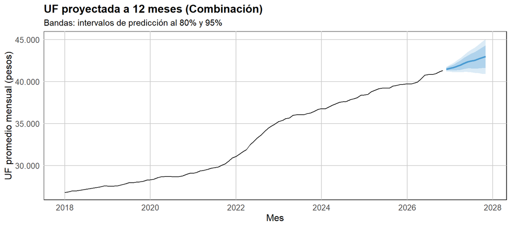

```r
# UF observada seguida de la proyectada: es la que usa el presupuesto
uf_meses <- tibble::tibble(
  mes = seq(min(uf_mensual$mes), by = "month", length.out = nrow(uf_mensual) + 12),
  uf  = c(uf_mensual$uf, cv_uf$media)
)

proy_uf <- tibble::tibble(
  mes = tail(uf_meses$mes, 12), valor = cv_uf$media,
  inf80 = cv_uf$inferior[, 1], sup80 = cv_uf$superior[, 1], inf95 = cv_uf$inferior[, 2], sup95 = cv_uf$superior[, 2]
)

grafico_proyeccion(dplyr::rename(uf_mensual, valor = uf), proy_uf,
                   paste0("UF proyectada a 12 meses (", cv_uf$mejor, ")"), "UF promedio mensual (pesos)") +
  scale_y_continuous(labels = function(x) format(x, big.mark = ".", decimal.mark = ","))
```

```r
proy_uf %>%
  dplyr::transmute(Mes = format(mes, "%m/%Y"), `UF proyectada` = valor, `Mínimo 95%` = inf95, `Máximo 95%` = sup95) %>%
  knitr::kable("markdown", digits = 0, format.args = list(big.mark = ".", decimal.mark = ","),
               caption = "UF promedio mensual proyectada (pesos)")
```

UF promedio mensual proyectada (pesos)

| Mes | UF proyectada | Mínimo 95% | Máximo 95% |
| --- | --- | --- | --- |
| 12/2026 | 41.486 | 41.234 | 41.737 |
| 01/2027 | 41.594 | 41.187 | 42.001 |
| 02/2027 | 41.688 | 41.135 | 42.241 |
| 03/2027 | 41.841 | 41.141 | 42.542 |
| 04/2027 | 41.969 | 41.118 | 42.821 |
| 05/2027 | 42.172 | 41.165 | 43.180 |
| 06/2027 | 42.339 | 41.170 | 43.508 |
| 07/2027 | 42.448 | 41.111 | 43.785 |
| 08/2027 | 42.543 | 41.033 | 44.053 |
| 09/2027 | 42.689 | 41.000 | 44.378 |
| 10/2027 | 42.831 | 40.957 | 44.705 |
| 11/2027 | 42.990 | 40.925 | 45.054 |

# 3. Presupuesto proyectado

El gasto de cada mes se convierte a UF para descontar la inflación, se proyecta en UF y se vuelve a pesos con la UF proyectada: así la proyección ya incluye el alza esperada de precios. El mes en curso queda fuera del ajuste porque está incompleto.

```r
# Arriendo que no se registra en la planilla; en la proyección se reajusta según la UF
arriendo_mensual <- 860000

gasto_mensual <- gasto_mes_cat %>%
  dplyr::filter(mes < mes_actual) %>%
  dplyr::group_by(mes) %>%
  dplyr::summarise(gasto = sum(gasto)) %>%
  dplyr::left_join(uf_meses, by = "mes") %>%
  dplyr::mutate(gasto_uf = gasto / uf)

y_gasto <- ts(gasto_mensual$gasto_uf, frequency = 12,
              start = c(lubridate::year(min(gasto_mensual$mes)), lubridate::month(min(gasto_mensual$mes))))
```

```r
# Con caché: solo se recalcula cuando cambia la serie de meses completos, es decir, una vez al mes
cv_gasto    <- compite(y_gasto, modelos)
tbats_gasto <- forecast::tbats(y_gasto, use.box.cox = FALSE, use.parallel = FALSE)   # sin Box-Cox para que los componentes queden en UF
```

```r
uf_hoy <- tail(uf_mensual$uf, 1)

cv_gasto$tabla %>%
  dplyr::mutate(dplyr::across(-Modelo, ~ .x * uf_hoy / 1000)) %>%
  knitr::kable("markdown", digits = 0,
               caption = "Gasto: error absoluto medio al proyectar de 1 a 12 meses, en miles de pesos de hoy (gana el menor promedio)")
```

Gasto: error absoluto medio al proyectar de 1 a 12 meses, en miles de pesos de hoy (gana el menor promedio)

| Modelo | Ventana expansiva | Ventana móvil | Últimos 12 meses | Promedio |
| --- | --- | --- | --- | --- |
| ARIMA | 210 | 212 | 263 | 228 |
| Combinación | 234 | 227 | 289 | 250 |
| ETS | 239 | 247 | 310 | 266 |
| Theta | 243 | 256 | 314 | 271 |
| TBATS | 273 | 231 | 320 | 275 |
| Naive estacional | 313 | 313 | 356 | 327 |

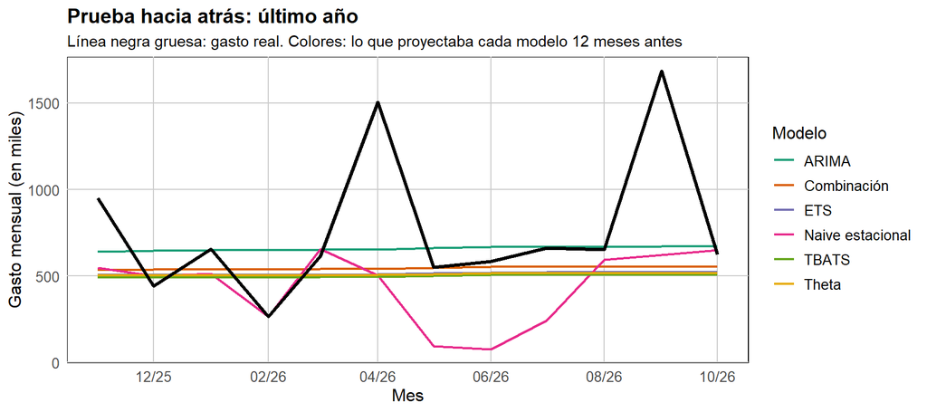

```r
# Lo que cada modelo habría proyectado para el último año sin haberlo visto, contra lo que pasó
ultimo_anio <- tail(gasto_mensual, 12)

tibble::as_tibble(cv_gasto$ultimo_anio * ultimo_anio$uf / 1000) %>%
  dplyr::mutate(mes = ultimo_anio$mes) %>%
  tidyr::pivot_longer(-mes, names_to = "Modelo", values_to = "gasto") %>%
  ggplot(aes(x = mes, y = gasto)) +
  geom_line(aes(color = Modelo), linewidth = 0.8) +
  geom_line(data = ultimo_anio, aes(y = gasto / 1000), linewidth = 1.2) +
  scale_color_brewer(palette = "Dark2") +
  scale_x_date(date_breaks = "2 months", date_labels = "%m/%y") +
  labs(x = "Mes", y = "Gasto mensual (en miles)", title = "Prueba hacia atrás: último año",
       subtitle = "Línea negra gruesa: gasto real. Colores: lo que proyectaba cada modelo 12 meses antes") +
  theme_custom()
```

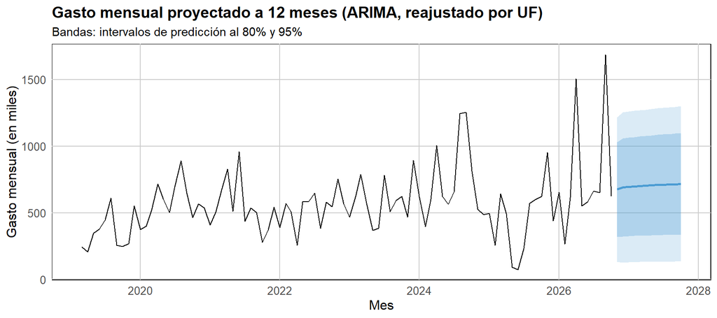

```r
# shortcut: los intervalos solo reflejan la incertidumbre del gasto, no la de la UF, que es mucho menor
proy_gasto <- tibble::tibble(mes = seq(mes_actual, by = "month", length.out = 12)) %>%
  dplyr::left_join(uf_meses, by = "mes") %>%
  dplyr::mutate(
    gasto_uf = cv_gasto$media,
    valor    = gasto_uf * uf / 1000,
    inf80    = pmax(0, cv_gasto$inferior[, 1]) * uf / 1000, sup80 = cv_gasto$superior[, 1] * uf / 1000,
    inf95    = pmax(0, cv_gasto$inferior[, 2]) * uf / 1000, sup95 = cv_gasto$superior[, 2] * uf / 1000,
    arriendo = arriendo_mensual * uf / uf[1] / 1000
  )

grafico_proyeccion(dplyr::transmute(gasto_mensual, mes, valor = gasto / 1000), proy_gasto,
                   paste0("Gasto mensual proyectado a 12 meses (", cv_gasto$mejor, ", reajustado por UF)"),
                   "Gasto mensual (en miles)")
```

```r
gastado_mes <- sum(gasto_mes_cat$gasto[gasto_mes_cat$mes == mes_actual]) / 1000
miles <- function(x) format(round(x), big.mark = ".", decimal.mark = ",")

cat("En ", format(mes_actual, "%m/%Y"), " van gastados **", miles(gastado_mes), " mil** de un presupuesto proyectado de **",
    miles(proy_gasto$valor[1]), " mil** (", round(100 * gastado_mes / proy_gasto$valor[1]), "%).\n\n", sep = "")
```

En 11/2026 van gastados **227 mil** de un presupuesto proyectado de **675 mil** (34%).

```r
proy_gasto %>%
  dplyr::transmute(
    Mes = format(mes, "%m/%Y"), `UF` = uf, `Gasto en UF` = gasto_uf, `Proyección` = valor,
    `Mínimo 80%` = inf80, `Máximo 80%` = sup80, `Máximo 95%` = sup95,
    `Arriendo reajustado` = arriendo, `Proyección + arriendo` = valor + arriendo
  ) %>%
  knitr::kable("markdown", digits = c(0, 0, 1, 0, 0, 0, 0, 0, 0), format.args = list(big.mark = ".", decimal.mark = ","),
               caption = "Presupuesto proyectado por mes, en miles de pesos (UF en pesos)") %>%
  print()
```

Presupuesto proyectado por mes, en miles de pesos (UF en pesos)

| Mes | UF | Gasto en UF | Proyección | Mínimo 80% | Máximo 80% | Máximo 95% | Arriendo reajustado | Proyección + arriendo |
| --- | --- | --- | --- | --- | --- | --- | --- | --- |
| 11/2026 | 41.342 | 16,3 | 675 | 320 | 1.029 | 1.217 | 860 | 1.535 |
| 12/2026 | 41.486 | 16,6 | 690 | 321 | 1.058 | 1.253 | 863 | 1.553 |
| 01/2027 | 41.594 | 16,7 | 695 | 325 | 1.065 | 1.261 | 865 | 1.560 |
| 02/2027 | 41.688 | 16,7 | 697 | 326 | 1.068 | 1.264 | 867 | 1.564 |
| 03/2027 | 41.841 | 16,7 | 700 | 328 | 1.072 | 1.269 | 870 | 1.570 |
| 04/2027 | 41.969 | 16,7 | 702 | 329 | 1.076 | 1.273 | 873 | 1.575 |
| 05/2027 | 42.172 | 16,7 | 706 | 331 | 1.081 | 1.279 | 877 | 1.583 |
| 06/2027 | 42.339 | 16,7 | 709 | 332 | 1.085 | 1.285 | 881 | 1.589 |
| 07/2027 | 42.448 | 16,7 | 710 | 333 | 1.088 | 1.288 | 883 | 1.593 |
| 08/2027 | 42.543 | 16,7 | 712 | 333 | 1.090 | 1.291 | 885 | 1.597 |
| 09/2027 | 42.689 | 16,7 | 714 | 335 | 1.094 | 1.295 | 888 | 1.602 |
| 10/2027 | 42.831 | 16,7 | 717 | 336 | 1.098 | 1.299 | 891 | 1.608 |

```r
# shortcut: reparte el total según el peso de cada categoría en los últimos 12 meses; pasar a un modelo por categoría si sus tendencias divergen
prom_12m %>%
  dplyr::mutate(
    `% del gasto`         = 100 * `Promedio 12 meses` / sum(`Promedio 12 meses`),
    `Presupuesto mensual` = `% del gasto` / 100 * mean(proy_gasto$valor)
  ) %>%
  dplyr::select(-`Promedio 12 meses`) %>%
  dplyr::arrange(dplyr::desc(`Presupuesto mensual`)) %>%
  janitor::adorn_totals() %>%
  dplyr::rename(`Categoría` = categoria) %>%
  knitr::kable("markdown", digits = 0, caption = "Presupuesto mensual por categoría, promedio de los próximos 12 meses (miles de pesos)")
```

Presupuesto mensual por categoría, promedio de los próximos 12 meses (miles de pesos)

| Categoría | % del gasto | Presupuesto mensual |
| --- | --- | --- |
| Comida | 56 | 395 |
| Entretención | 13 | 92 |
| Electrodomesticos/mantencion casa | 11 | 76 |
| Diosi | 9 | 65 |
| Servicios básicos | 5 | 32 |
| Streaming/Telefonia | 2 | 14 |
| Transporte | 2 | 12 |
| Otros | 1 | 10 |
| Enceres | 1 | 5 |
| Donaciones/regalos | 0 | 1 |
| Farmacia | 0 | 0 |
| Total | 100 | 702 |

## Tendencia del gasto

Descomposición TBATS del gasto mensual en UF, es decir, descontada la inflación: el nivel muestra hacia dónde va el gasto real una vez quitado el ruido de cada mes.

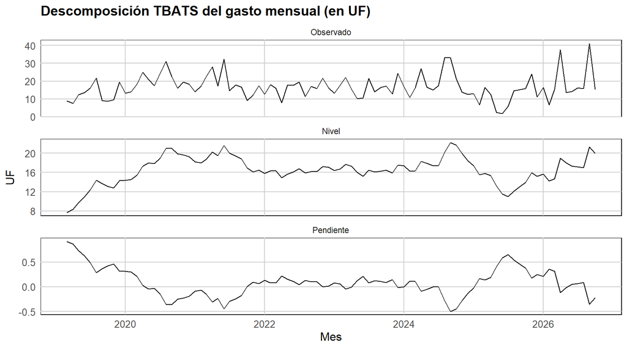

```r
nombres_tbats <- c(observed = "Observado", level = "Nivel", slope = "Pendiente", season = "Estacionalidad")
componentes <- forecast::tbats.components(tbats_gasto)

tibble::as_tibble(componentes) %>%
  dplyr::mutate(mes = gasto_mensual$mes) %>%
  tidyr::pivot_longer(-mes, names_to = "componente", values_to = "valor") %>%
  dplyr::mutate(componente = dplyr::coalesce(unname(nombres_tbats[componente]), componente),
                componente = factor(componente, levels = unique(componente))) %>%
  ggplot(aes(x = mes, y = valor)) +
  geom_line() +
  facet_wrap(~ componente, ncol = 1, scales = "free_y") +
  labs(x = "Mes", y = "UF", title = "Descomposición TBATS del gasto mensual (en UF)") +
  theme_custom()
```

# 4. Análisis históricos

[figure not shown]

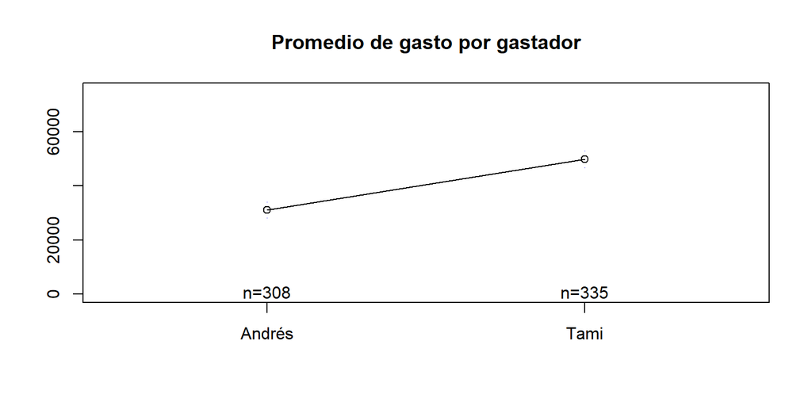

```r
#para ver las diferencias depués de la diosi
Gastos_casa %>%
    dplyr::mutate(fecha= lubridate::parse_date_time(fecha, c("%d/%m/%Y"),exact=T)) %>%
    dplyr::mutate(fecha=strftime(fecha, format = "%Y-W%V")) %>%
    dplyr::mutate(gastador=ifelse(gastador=="Andrés",1,0)) %>%
    dplyr::group_by(gastador, fecha,.drop = F) %>%
    dplyr::summarise(gasto_media=mean(monto,na.rm=T)) %>%
    dplyr::mutate(treat=ifelse(fecha>"2019-W26",1,0)) %>%
    #dplyr::mutate(fecha_simp=lubridate::week(fecha)) %>%#después de  diosi. Junio 24, 2019
    dplyr::mutate(gastador_nombre=plyr::revalue(as.character(gastador), c("0" = "Tami", "1"="Andrés"))) %>%
    assign("ts_gastos_casa_week_treat", ., envir = .GlobalEnv)

gplots::plotmeans(gasto_media ~ gastador_nombre, main="Promedio de gasto por gastador", data=ts_gastos_casa_week_treat,ylim=c(0,75000), xlab="", ylab="")
```

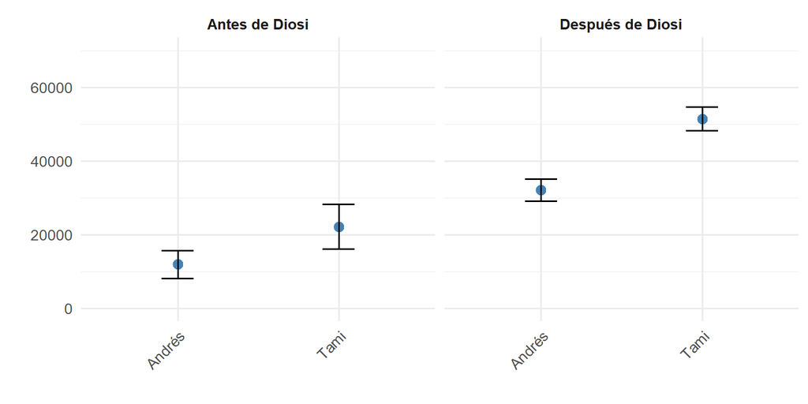

```r
library(ggplot2)

ggplot(
  ts_gastos_casa_week_treat,
  aes(x = gastador_nombre, y = gasto_media)
) +
  stat_summary(fun = mean, geom = "point", size = 3, color = "steelblue") +
  stat_summary(fun.data = mean_cl_normal, geom = "errorbar", width = 0.2) +
  facet_wrap(~ treat, labeller = labeller(
    treat = c(`0` = "Antes de Diosi", `1` = "Después de Diosi")
  )) +
  coord_cartesian(ylim = c(0, 70000)) +
  labs(x = "", y = "") +
  theme_minimal(base_size = 13) +
  theme(
    strip.text = element_text(face = "bold"),
    axis.text.x = element_text(angle = 45, hjust = 1)
  )
```

```r
library(ggiraph)
library(scales)
#if( requireNamespace("dplyr", quietly = TRUE)){
gg <- Gastos_casa %>%
  dplyr::mutate(fecha= lubridate::parse_date_time(fecha, c("%d/%m/%Y"),exact=T)) %>%
  dplyr::mutate(gastador=ifelse(gastador=="Andrés",1,0)) %>%
  dplyr::mutate(fecha_simp=tsibble::yearweek(fecha)) %>%
  dplyr::mutate(fecha_week=strftime(fecha, format = "%Y-W%V")) %>%
  dplyr::mutate(treat=ifelse(fecha_week>"2019 W26",1,0)) %>%
  dplyr::mutate(gastador_nombre=plyr::revalue(as.character(gastador), c("0" = "Tami", "1"="Andrés"))) %>%
#  dplyr::mutate(week=as.Date(as.character(lubridate::floor_date(fecha, "week"))))%>%
  #dplyr::mutate(fecha_week= lubridate::parse_date_time(fecha_week, c("%Y-W%V"),exact=T)) %>%
  dplyr::group_by(gastador_nombre, fecha_simp) %>%
  dplyr::summarise(monto_total=sum(monto)) %>%
  dplyr::mutate(tooltip= paste0(substr(gastador_nombre,1,1),"=",round(monto_total/1000,2))) %>%
  ggplot(aes(hover_css = "fill:none;")) +#, ) +
  #stat_summary(geom = "line", fun.y = median, size = 1, alpha=0.5, aes(color="blue")) +
  geom_line(aes(x = fecha_simp, y = monto_total, color=as.factor(gastador_nombre)),size=1,alpha=.5) +
                       ggiraph::geom_point_interactive(aes(x = fecha_simp, y = monto_total, color=as.factor(gastador_nombre),tooltip=tooltip),size = 1) +
  #geom_text(aes(x = fech_ing_qrt, y = perc_dup-0.05, label = paste0(n)), vjust = -1,hjust = 0, angle=45, size=3) +
 # guides(color = F)+
  theme_custom() +
  geom_vline(xintercept = as.Date("2019-06-24"),linetype = "dashed") +
  labs(y="Gastos (en miles)",x="Semanas y Meses", subtitle="Interlineado, incorporación de la Diosi; Azul= Tami; Rojo= Andrés") + ggtitle( "Figura 4. Gastos por Gastador") +
  scale_y_continuous(labels = f <- function(x) paste0(x/1000)) +
  scale_color_manual(name = "Gastador", values= c("blue", "red"), labels = c("Tami", "Andrés")) +
  tsibble::scale_x_yearweek(date_breaks = "1 month", minor_breaks = "1 week", labels=scales::date_format("%m/%y")) +
  theme(axis.text.x = element_text(vjust = 0.5,angle = 35), legend.position='bottom')+
     theme(
    panel.border = element_blank(),
    panel.grid.major = element_blank(),
    panel.grid.minor = element_blank(),
    axis.line = element_line(colour = "black")
    )

#  x <- girafe(ggobj = gg)
#  x <- girafe_options(x = x,
#                      opts_hover(css = "stroke:red;fill:orange") )
#  if( interactive() ) print(x)

#}
tooltip_css <- "background-color:gray;color:white;font-style:italic;padding:10px;border-radius:10px 20px 10px 20px;"

#ggiraph(code = {print(gg)}, tooltip_extra_css = tooltip_css, tooltip_opacity = .75 )

x <- girafe(ggobj = gg)
x <- girafe_options(x,
  opts_zoom(min = 1, max = 3), opts_hover(css =tooltip_css))
```

```r
x
```

[interactive chart not shown]

```r
plot<-Gastos_casa %>%
    dplyr::mutate(fecha= lubridate::parse_date_time(fecha, c("%d/%m/%Y"),exact=T)) %>%
    dplyr::mutate(fecha_week=strftime(fecha, format = "%Y-W%V")) %>%
    dplyr::mutate(month=as.Date(as.character(lubridate::floor_date(fecha, "month"))))%>%
    dplyr::group_by(month)%>%
    dplyr::summarise(gasto_total=sum(monto)/1000) %>%
      ggplot2::ggplot(aes(x = month, y = gasto_total)) +
      geom_point()+
      geom_line(size=1) +
      theme_custom() +
      geom_vline(xintercept = as.Date("2019-06-24"),linetype = "dashed") +
      geom_vline(xintercept = as.Date("2019-03-23"),linetype = "dashed", color="red") +
      labs(y="Gastos (en miles)",x="Meses/Año", subtitle="Interlineado, incorporación de la Diosi") +
      ggtitle( "Figura. Suma de Gastos por Mes") +
      scale_x_date(breaks = "1 month", minor_breaks = "1 month", labels=scales::date_format("%m/%y")) +
      theme(axis.text.x = element_text(vjust = 0.5,angle = 45))
plotly::ggplotly(plot)
```

[interactive chart not shown]

```r
plot2<-Gastos_casa %>%
    dplyr::mutate(fecha= lubridate::parse_date_time(fecha, c("%d/%m/%Y"),exact=T)) %>%
    dplyr::mutate(fecha_week=strftime(fecha, format = "%Y-W%V")) %>%
    dplyr::mutate(day=as.Date(as.character(lubridate::floor_date(fecha, "day"))))%>%
    dplyr::group_by(day)%>%
    summarise(gasto_total=sum(monto)/1000) %>%
      ggplot2::ggplot(aes(x = day, y = gasto_total)) +
      geom_line(size=1) +
      theme_custom() +
      geom_vline(xintercept = as.Date("2019-06-24"),linetype = "dashed") +
      geom_vline(xintercept = as.Date("2020-03-23"),linetype = "dashed", color="red") +
      labs(y="Gastos (en miles)",x="Meses/Año", subtitle="Interlineado, incorporación de la Diosi") +
      ggtitle( "Figura. Suma de Gastos por Día") +
      scale_x_date(breaks = "1 month", minor_breaks = "1 week", labels=scales::date_format("%m/%y")) +
      theme(axis.text.x = element_text(vjust = 0.5,angle = 45))
plotly::ggplotly(plot2)
```

[interactive chart not shown]

```r
tsData <- Gastos_casa %>%
    dplyr::mutate(fecha= lubridate::parse_date_time(fecha, c("%d/%m/%Y"),exact=T)) %>%
    dplyr::mutate(fecha_week=strftime(fecha, format = "%Y-W%V")) %>%
    dplyr::mutate(day=as.Date(as.character(lubridate::floor_date(fecha, "day"))))%>%
    dplyr::group_by(day)%>%
    summarise(gasto_total=sum(monto))%>%
    dplyr::mutate(covid=case_when(day>as.Date("2019-06-02")~1,TRUE~0))%>%
    dplyr::mutate(covid=case_when(day>as.Date("2020-03-10")~covid+1,TRUE~covid))%>%
    dplyr::mutate(covid=as.factor(covid))%>%
  data.frame()
```

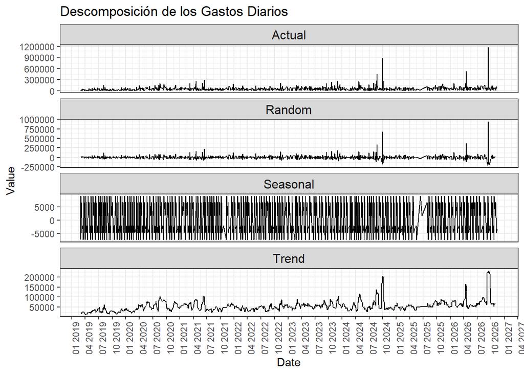

```r
tsData_gastos <-ts(tsData$gasto_total, frequency=7)
mstsData_gastos <- forecast::msts(Gastos_casa$monto, seasonal.periods=c(7,30))

tsData_gastos = decompose(tsData_gastos)

tsdata_gastos_trend<-cbind(tsData,trend=as.vector(tsData_gastos$trend))%>% na.omit()

# Assuming your time series starts on "2019-03-03"
start_date <- as.Date("2019-03-03")
frequency <- 7  # Weekly data
num_periods <- length(tsData_gastos$x)  # Total number of periods in your time series

# Generate sequence of dates
dates <- tsData$day# seq.Date(from = start_date, by = "day", length.out = num_periods)

# Create a data frame from the decomposed time series object
tsData_gastos_df <- data.frame(
  day = dates,
  Actual = as.numeric(tsData_gastos$x),
  Seasonal = as.numeric(tsData_gastos$seasonal),
  Trend = as.numeric(tsData_gastos$trend),
  Random = as.numeric(tsData_gastos$random)
)

tsData_gastos_long <- tsData_gastos_df %>%
  pivot_longer(cols = c("Actual", "Seasonal", "Trend", "Random"),
               names_to = "Component", values_to = "Value")

# Plotting with facet_wrap
ggplot(tsData_gastos_long, aes(x = day, y = Value)) +
  geom_line() +
  theme_bw() +
  labs(title = "Descomposición de los Gastos Diarios", x = "Date", y = "Value") +
  scale_x_date(date_breaks = "3 months", date_labels = "%m %Y") +
  facet_wrap(~ Component, scales = "free_y", ncol=1) +
theme(axis.text.x = element_text(angle = 90, hjust = 1))+
  theme(strip.text = element_text(size = 12))
```

Ahora con las tendencias descompuestas

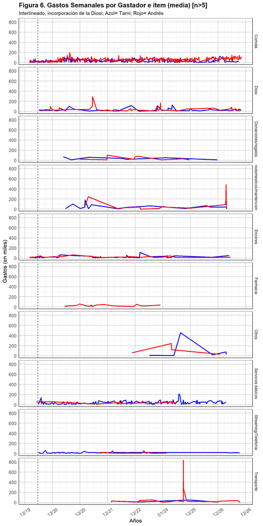

```r
#require(zoo)
Gastos_casa_gastador_cat_gasto<-
Gastos_casa %>%
    dplyr::mutate(fecha = fecha_d, gastador=ifelse(gastador=="Andrés",1,0)) %>%
    dplyr::group_by(gastador, fecha, categoria, .drop=F) %>%
    dplyr::summarise(monto=sum(monto)) %>%
    dplyr::mutate(gastador_nombre=plyr::revalue(as.character(gastador), c("0" = "Tami", "1"="Andrés")))




Gastos_casa_gastador_cat_gasto %>%
    dplyr::mutate(fecha = as.Date(fecha)) %>%       # por si viene como POSIXct
    dplyr::group_by(categoria) %>%                     # opcional: quita ítems con 1 obs
    dplyr::filter(n() >= 6) %>%
    dplyr::ungroup() %>%
ggplot2::ggplot(aes(x = fecha, y = monto, color=as.factor(gastador_nombre))) +
  #stat_summary(geom = "line", fun.y = median, size = 1, alpha=0.5, aes(color="blue")) +
  geom_line(size=1) +
  facet_grid(categoria~.)+
  geom_vline(xintercept = as.Date("2019-06-24"),linetype = "dashed") +
  labs(y="Gastos (en miles)",x="Años", subtitle="Interlineado, incorporación de la Diosi; Azul= Tami; Rojo= Andrés") +
  ggtitle( "Figura 6. Gastos Semanales por Gastador e ítem (media) [n>5]") +
  scale_y_continuous(labels = f <- function(x) paste0(x/1000)) +
  scale_color_manual(name = "Gastador", values= c("blue", "red"), labels = c("Tami", "Andrés")) +
  tsibble::scale_x_yearweek(breaks = "1 year", minor_breaks = "3 months", labels= scales::date_format("%m/%y")) +
  guides(color = F)+
  theme_custom() +
  theme(axis.text.x = element_text(vjust = 0.5,angle = 35)) +
  theme(
    panel.border = element_blank(),
    #panel.grid.major = element_blank(),
    #panel.grid.minor = element_blank(),
    panel.grid.minor = element_line(color = "grey90", size = 0.3),
    panel.grid.major = element_line(color = "grey75", size = 0.5),
    axis.line = element_line(colour = "black")
    )
```

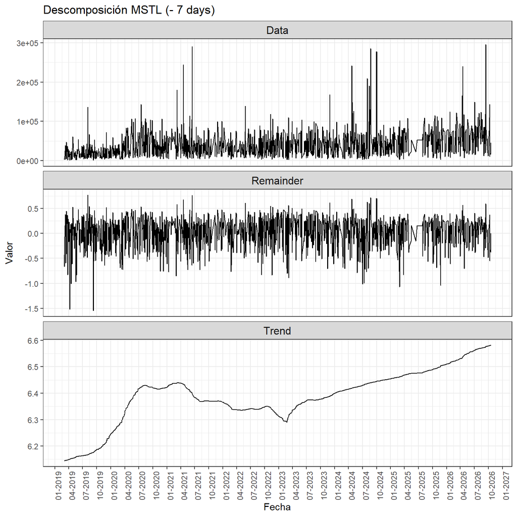

```r
# Apply MSTL decomposition

Gastos_casa |>
    dplyr::mutate(fecha= readr::parse_date(fecha, format="%d/%m/%Y")) |>
    dplyr::arrange(fecha) |>  pull(monto) -> monto_ts
Gastos_casa |>
    dplyr::mutate(fecha= readr::parse_date(fecha, format="%d/%m/%Y")) |>
    dplyr::arrange(fecha) |>  pull(fecha) -> fecha_ts

mstl_data_autplt <- forecast::mstl(monto_ts, lambda = "auto",iterate=5000000,start =
lubridate::decimal_date(as.Date("2019-03-03")))

# Convert the decomposed time series to a data frame
mstl_df <- data.frame(
  Date = as.Date(fecha_ts, format="%d/%m/%Y"),
  Data = as.numeric(mstl_data_autplt[, "Data"]),
  Trend = as.numeric(mstl_data_autplt[, "Trend"]),
  Remainder = as.numeric(mstl_data_autplt[, "Remainder"])
)

# Reshape the data frame for ggplot2
mstl_long <- mstl_df %>%
  dplyr::arrange(Date) %>%
  tidyr::pivot_longer(cols = -Date, names_to = "Component", values_to = "Value")

mstl_long_filtered <- mstl_long %>% dplyr::filter(!(Date %in% (mstl_long %>% dplyr::distinct(Date) %>% top_n(7, Date) %>% pull(Date))))

# Plotting with ggplot2
ggplot(mstl_long_filtered, aes(x = Date, y = Value)) +
  geom_line() +
  theme_bw() +
  labs(title = "Descomposición MSTL (- 7 days)", x = "Fecha", y = "Valor") +
  scale_x_date(date_breaks = "3 months", date_labels = "%m-%Y") +
  facet_wrap(~ Component, scales = "free_y", ncol = 1) +
  theme(strip.text = element_text(size = 12),
        axis.text.x = element_text(angle = 90, hjust = 1))
```

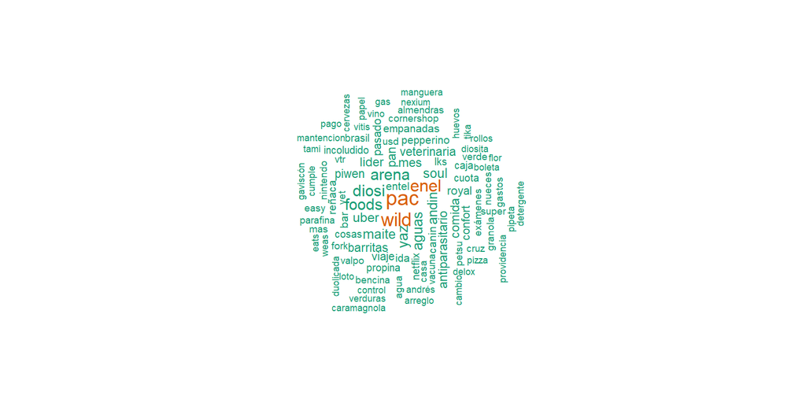

[figure not shown]

```r
# 1) Create corpus
corpus <- tm::Corpus(tm::VectorSource(Gastos_casa$obs))

# 2) Preprocess text
d <- corpus |>
  tm::tm_map(tm::content_transformer(tolower)) |>
  tm::tm_map(tm::stripWhitespace) |>
  tm::tm_map(tm::removePunctuation) |>
  tm::tm_map(tm::removeNumbers) |>
  tm::tm_map(tm::removeWords, tm::stopwords("spanish")) |>
  tm::tm_map(tm::removeWords, "menos")

# 3) Term-document matrix
tdm <- tm::TermDocumentMatrix(d)

# 4) Convert to matrix
m <- base::as.matrix(tdm)

# 5) Frequencies
v  <- base::sort(base::rowSums(m), decreasing = TRUE)

df <- base::data.frame(
  word = base::names(v),
  freq = v,
  row.names = NULL
)

# 6) Wordcloud
wordcloud::wordcloud(
  words       = df$word,
  freq        = df$freq,
  max.words   = 100,
  random.order= FALSE,
  rot.per     = 0.35,
  colors      = RColorBrewer::brewer.pal(8, "Dark2"),
  scale       = c(4, 0.5)
)
```

# 5. Gastos mensuales (resumen manual)

```r
path_sec2<- paste0("https://docs.google.com/spreadsheets/d/",Sys.getenv("SUPERSECRET"),"/export?format=csv&id=",Sys.getenv("SUPERSECRET"),"&gid=847461368")

Gastos_casa_mensual_2022 <- readr::read_csv(as.character(path_sec2),
                #col_names = c("Tiempo", "gasto", "fecha", "obs", "monto", "gastador","link"),
                skip=0)
head(Gastos_casa_mensual_2022,5) %>%
  knitr::kable("markdown",caption="Resumen mensual, primeras 5 observaciones")
```

Resumen mensual, primeras 5 observaciones

| n | mes_ano | Tami | Andrés |
| --- | --- | --- | --- |
| 1 | marzo_2019 | 175533 | 68268 |
| 2 | abril_2019 | 152640 | 55031 |
| 3 | mayo_2019 | 152985 | 192219 |
| 4 | junio_2019 | 291067 | 84961 |
| 5 | julio_2019 | 241389 | 205893 |

```r
(
Gastos_casa_mensual_2022 %>%
    reshape2::melt(id.var=c("n","mes_ano")) %>%
  dplyr::mutate(gastador=as.factor(variable)) %>%
  dplyr::select(-variable) %>%
 ggplot2::ggplot(aes(x = n, y = value, color=gastador)) +
  scale_color_manual(name="Gastador", values=c("red", "blue"))+
  geom_line(size=1) +
  #geom_vline(xintercept = as.Date("2019-06-24"),linetype = "dashed") +
  labs(y="Gastos (en miles)",x="Meses", subtitle="Azul= Tami; Rojo= Andrés") +
  ggtitle( "Gastos Mensuales (total manual)") +
  scale_y_continuous(labels = f <- function(x) paste0(x/1000)) +
#  scale_color_manual(name = "Gastador", values= c("blue", "red"), labels = c("Tami", "Andrés")) +
#  scale_x_yearweek(breaks = "1 month", minor_breaks = "1 week", labels=date_format("%m/%y")) +
 # guides(color = F)+
  theme_custom() +
  theme(axis.text.x = element_text(vjust = 0.5,angle = 35)) +
  theme(
    panel.border = element_blank(),
    panel.grid.major = element_blank(),
    panel.grid.minor = element_blank(),
    axis.line = element_line(colour = "black")
    )
) %>% ggplotly()
```

[interactive chart not shown]

# Session Info

```r
Sys.getenv("R_LIBS_USER")
```

```
## [1] "D:\\a\\_temp\\Library"
```

```r
#save.image("__analisis.RData")

sesion_info <- sessioninfo::session_info()
dplyr::select(
  tibble::as_tibble(sesion_info$packages),
  c(package, loadedversion, source)
) %>%
  DT::datatable(filter = 'top', colnames = c('Row number' =1,'Variable' = 2, 'Percentage'= 3),
              caption = htmltools::tags$caption(
        style = 'caption-side: top; text-align: left;',
        '', htmltools::em('Packages')),
      options=list(
initComplete = htmlwidgets::JS(
        "function(settings, json) {",
        "$(this.api().tables().body()).css({
            'font-family': 'Helvetica Neue',
            'font-size': '50%',
            'code-inline-font-size': '15%',
            'white-space': 'nowrap',
            'line-height': '0.75em',
            'min-height': '0.5em'
            });",#;
        "}")))
```

| Row number | Variable | Percentage | source |
| --- | --- | --- | --- |
| 1 | anytime | 0.3.13 | RSPM |
| 2 | backports | 1.5.1 | RSPM |
| 3 | base64enc | 0.1-6 | RSPM |
| 4 | bit | 4.6.0 | RSPM |
| 5 | bit64 | 4.8.6 | RSPM |
| 6 | bitops | 1.1-0 | RSPM |
| 7 | bslib | 0.12.0 | RSPM |
| 8 | cachem | 1.1.0 | RSPM |
| 9 | caTools | 1.18.4 | RSPM |
| 10 | checkmate | 2.3.4 | RSPM |

[output cut: 101 more lines]